# Practical Machine Learning - Course Project

Gabriel

12/11/2021

## Introduction

Using devices such as Jawbone Up, Nike FuelBand, and Fitbit it is now possible to collect a large amount of data about personal activity relatively inexpensively. These type of devices are part of the quantified self movement – a group of enthusiasts who take measurements about themselves regularly to improve their health, to find patterns in their behavior, or because they are tech geeks. One thing that people regularly do is quantify how much of a particular activity they do, but they rarely quantify how well they do it. The data for this project come from this source: http://groupware.les.inf.puc-rio.br/har.

The training data for this project were downloaded from: https://d396qusza40orc.cloudfront.net/predmachlearn/pml-training.csv

The test data were downloaded from: https://d396qusza40orc.cloudfront.net/predmachlearn/pml-testing.csv

The goal of this project is to use data from accelerometers on the belt, forearm, arm, and dumbell of 6 participants. The participants were asked to perform barbell lifts correctly and incorrectly in 5 different ways. This is the “classe” variable in the training set and the other measurements will be used to predict classe. The report will describe the preprocessing, cross validation and model building used to make the prediction. In the end, we will choose the machine learning algorithm with the highest accuracy to apply to the test data.

## Model building and selection

First, we will download the .csv files for the training and test data and create two data frames.

```r
library(ggplot2)
library(lattice)
library(caret)
library(rattle)

train_URL <-"http://d396qusza40orc.cloudfront.net/predmachlearn/pml-training.csv"
test_URL <- "http://d396qusza40orc.cloudfront.net/predmachlearn/pml-testing.csv"

if (!file.exists("pml-training.csv")) {
  download.file(train_URL, destfile = "pml-training.csv", method = "curl")
}

train_data <- read.csv("pml-training.csv", header = TRUE)

if (!file.exists("pml-testing.csv")) {
  download.file(test_URL, destfile = "pml-testing.csv", method = "curl")
}

test_data <- read.csv("pml-testing.csv", header = TRUE)
```

The first step of building the model is to inspect the training data and remove any variables that we will not use in the final model.

```r
head(train_data[1:7],5)
```

```
##   X user_name raw_timestamp_part_1 raw_timestamp_part_2   cvtd_timestamp
## 1 1  carlitos           1323084231               788290 05/12/2011 11:23
## 2 2  carlitos           1323084231               808298 05/12/2011 11:23
## 3 3  carlitos           1323084231               820366 05/12/2011 11:23
## 4 4  carlitos           1323084232               120339 05/12/2011 11:23
## 5 5  carlitos           1323084232               196328 05/12/2011 11:23
##   new_window num_window
## 1         no         11
## 2         no         11
## 3         no         11
## 4         no         12
## 5         no         12
```

```r
train_data <- train_data[,-c(1:7)]
```

The first 7 variables contain timestamps, usernames and other data that should not have an effect on the outcome of our prediction so we can safely remove them.

```r
dim(train_data)
```

```
## [1] 19622   153
```

```r
colSums(is.na(train_data))[colSums(is.na(train_data))!=0]
```

```
##            max_roll_belt           max_picth_belt            min_roll_belt
##                    19216                    19216                    19216
##           min_pitch_belt      amplitude_roll_belt     amplitude_pitch_belt
##                    19216                    19216                    19216
##     var_total_accel_belt            avg_roll_belt         stddev_roll_belt
##                    19216                    19216                    19216
##            var_roll_belt           avg_pitch_belt        stddev_pitch_belt
##                    19216                    19216                    19216
##           var_pitch_belt             avg_yaw_belt          stddev_yaw_belt
##                    19216                    19216                    19216
##             var_yaw_belt            var_accel_arm             avg_roll_arm
##                    19216                    19216                    19216
##          stddev_roll_arm             var_roll_arm            avg_pitch_arm
##                    19216                    19216                    19216
##         stddev_pitch_arm            var_pitch_arm              avg_yaw_arm
##                    19216                    19216                    19216
##           stddev_yaw_arm              var_yaw_arm             max_roll_arm
##                    19216                    19216                    19216
##            max_picth_arm              max_yaw_arm             min_roll_arm
##                    19216                    19216                    19216
##            min_pitch_arm              min_yaw_arm       amplitude_roll_arm
##                    19216                    19216                    19216
##      amplitude_pitch_arm        amplitude_yaw_arm        max_roll_dumbbell
##                    19216                    19216                    19216
##       max_picth_dumbbell        min_roll_dumbbell       min_pitch_dumbbell
##                    19216                    19216                    19216
##  amplitude_roll_dumbbell amplitude_pitch_dumbbell       var_accel_dumbbell
##                    19216                    19216                    19216
##        avg_roll_dumbbell     stddev_roll_dumbbell        var_roll_dumbbell
##                    19216                    19216                    19216
##       avg_pitch_dumbbell    stddev_pitch_dumbbell       var_pitch_dumbbell
##                    19216                    19216                    19216
##         avg_yaw_dumbbell      stddev_yaw_dumbbell         var_yaw_dumbbell
##                    19216                    19216                    19216
##         max_roll_forearm        max_picth_forearm         min_roll_forearm
##                    19216                    19216                    19216
##        min_pitch_forearm   amplitude_roll_forearm  amplitude_pitch_forearm
##                    19216                    19216                    19216
##        var_accel_forearm         avg_roll_forearm      stddev_roll_forearm
##                    19216                    19216                    19216
##         var_roll_forearm        avg_pitch_forearm     stddev_pitch_forearm
##                    19216                    19216                    19216
##        var_pitch_forearm          avg_yaw_forearm       stddev_yaw_forearm
##                    19216                    19216                    19216
##          var_yaw_forearm
##                    19216
```

There are 153 variables and 19622 observations. First, we look for missing values. The table above shows all the variables that have at least 1 missing value. It looks like all of them have 19216 missing values. This is close to the total number of observations so we can completely remove these variables.

```r
train_data <- train_data[, colSums(is.na(train_data)) == 0]
nsv <- nearZeroVar(train_data)
train_data <- train_data[,-nsv]
```

We will also remove variables with near zero variability. This leaves us with 52 predictors plus the response variable “classe”.

One final step before cross-validation is to convert the “classe” variable to factor, which is very important for our model building.

```r
train_data$classe <- as.factor(train_data$classe)
```

For cross-validation, we will split the training data into the actual training and test sets using an 80/20 split as we have a fairly large data set. We also set a seed so that the results can be reproduced.

```r
set.seed(452)
inTrain <- createDataPartition(y=train_data$classe, p=0.8, list=F)
train <- train_data[inTrain,]
test <- train_data[-inTrain,]
```

Next, we will be building 3 models as follows:

- Decision Tree
- Bagging Method
- Random Forests

For all three models, we will apply a 5-fold cross validation using the trControl argument. A k=5 should be sufficient for a balance between bias and variance. We will also standardize the data using the preProcess argument with the parameters “center” and “scale”.

After training each model, we will predict using the test set from the 80/20 split and create a confusion matrix. This will produce a value for Accuracy, which is 1 minus the out of sample error. Therefore, the higher the accuracy, the better the model is.

The first model we train is the Decision Tree using Recursive Partitioning in R.

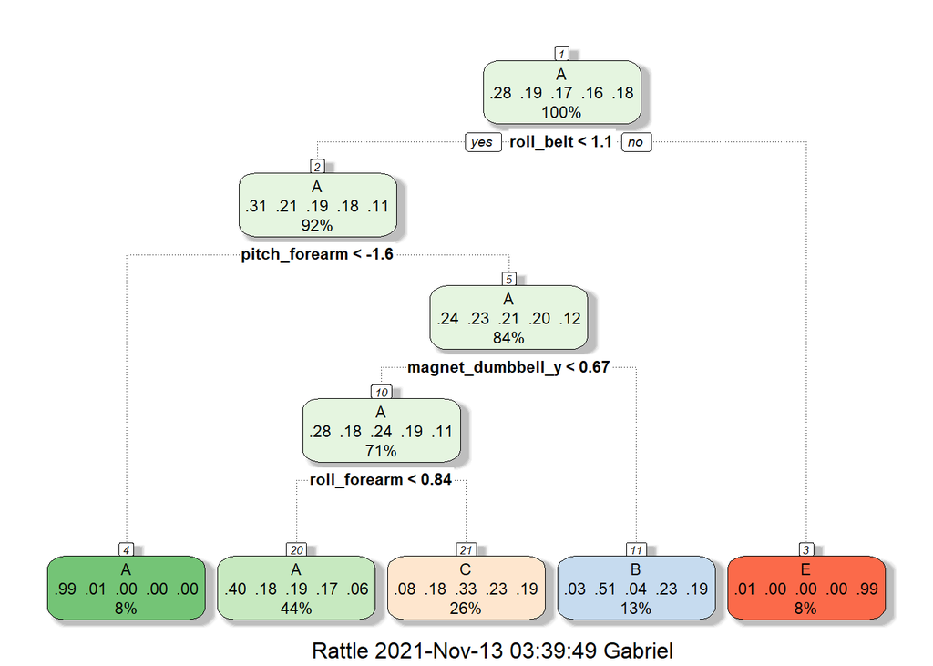

```r
modRpart <- train(classe~., data=train, method="rpart", trControl = trainControl(method="cv",number=5) ,preProcess=c("center", "scale"))
fancyRpartPlot(modRpart$finalModel)
```

```r
predRpart <- predict(modRpart, test)
cmRpart <- confusionMatrix(predRpart, test$classe)
cmRpart
```

```
## Confusion Matrix and Statistics
##
##           Reference
## Prediction    A    B    C    D    E
##          A 1023  308  299  277  101
##          B   17  263   22  107  111
##          C   75  188  363  259  184
##          D    0    0    0    0    0
##          E    1    0    0    0  325
##
## Overall Statistics
##
##                Accuracy : 0.5032
##                  95% CI : (0.4874, 0.519)
##     No Information Rate : 0.2845
##     P-Value [Acc > NIR] : < 0.00000000000000022
##
##                   Kappa : 0.3514
##
##  Mcnemar's Test P-Value : NA
##
## Statistics by Class:
##
##                      Class: A Class: B Class: C Class: D Class: E
## Sensitivity            0.9167  0.34651  0.53070   0.0000  0.45076
## Specificity            0.6491  0.91877  0.78203   1.0000  0.99969
## Pos Pred Value         0.5095  0.50577  0.33957      NaN  0.99693
## Neg Pred Value         0.9514  0.85425  0.88753   0.8361  0.88991
## Prevalence             0.2845  0.19347  0.17436   0.1639  0.18379
## Detection Rate         0.2608  0.06704  0.09253   0.0000  0.08284
## Detection Prevalence   0.5119  0.13255  0.27250   0.0000  0.08310
## Balanced Accuracy      0.7829  0.63264  0.65637   0.5000  0.72523
```

The second model is a bagging method using “treebag” in R.

```r
modBag <- train(classe~.,data=train, method = "treebag", trControl = trainControl(method="cv",number=5), preProcess=c("center", "scale"))
predBag <- predict(modBag, test)
cmBag <- confusionMatrix(predBag, test$classe)
cmBag
```

```
## Confusion Matrix and Statistics
##
##           Reference
## Prediction    A    B    C    D    E
##          A 1110   10    0    2    0
##          B    3  745    4    4    5
##          C    3    4  676   14    4
##          D    0    0    4  622    2
##          E    0    0    0    1  710
##
## Overall Statistics
##
##                Accuracy : 0.9847
##                  95% CI : (0.9804, 0.9883)
##     No Information Rate : 0.2845
##     P-Value [Acc > NIR] : < 0.00000000000000022
##
##                   Kappa : 0.9806
##
##  Mcnemar's Test P-Value : NA
##
## Statistics by Class:
##
##                      Class: A Class: B Class: C Class: D Class: E
## Sensitivity            0.9946   0.9816   0.9883   0.9673   0.9847
## Specificity            0.9957   0.9949   0.9923   0.9982   0.9997
## Pos Pred Value         0.9893   0.9790   0.9643   0.9904   0.9986
## Neg Pred Value         0.9979   0.9956   0.9975   0.9936   0.9966
## Prevalence             0.2845   0.1935   0.1744   0.1639   0.1838
## Detection Rate         0.2829   0.1899   0.1723   0.1586   0.1810
## Detection Prevalence   0.2860   0.1940   0.1787   0.1601   0.1812
## Balanced Accuracy      0.9952   0.9882   0.9903   0.9828   0.9922
```

The third and final model is the Random Forests.

```r
modRf <- train(classe~., data=train, method="rf", trControl = trainControl(method="cv",number=5), preProcess=c("center", "scale"))
predRf <- predict(modRf, test)
cmRf <- confusionMatrix(predRf, test$classe)
cmRf
```

```
## Confusion Matrix and Statistics
##
##           Reference
## Prediction    A    B    C    D    E
##          A 1114    6    0    0    0
##          B    1  747    1    1    0
##          C    1    6  678    5    3
##          D    0    0    5  637    2
##          E    0    0    0    0  716
##
## Overall Statistics
##
##                Accuracy : 0.9921
##                  95% CI : (0.9888, 0.9946)
##     No Information Rate : 0.2845
##     P-Value [Acc > NIR] : < 0.00000000000000022
##
##                   Kappa : 0.99
##
##  Mcnemar's Test P-Value : NA
##
## Statistics by Class:
##
##                      Class: A Class: B Class: C Class: D Class: E
## Sensitivity            0.9982   0.9842   0.9912   0.9907   0.9931
## Specificity            0.9979   0.9991   0.9954   0.9979   1.0000
## Pos Pred Value         0.9946   0.9960   0.9784   0.9891   1.0000
## Neg Pred Value         0.9993   0.9962   0.9981   0.9982   0.9984
## Prevalence             0.2845   0.1935   0.1744   0.1639   0.1838
## Detection Rate         0.2840   0.1904   0.1728   0.1624   0.1825
## Detection Prevalence   0.2855   0.1912   0.1767   0.1642   0.1825
## Balanced Accuracy      0.9980   0.9916   0.9933   0.9943   0.9965
```

```r
M <- matrix(c(cmRpart$overall[1],cmBag$overall[1],cmRf$overall[1]), ncol=3)
colnames(M)<-c("Trees","Bagging","Random Forest")
rownames(M) <- "Accuracy"
M
```

```
##              Trees   Bagging Random Forest
## Accuracy 0.5031863 0.9847056     0.9920979
```

Out of the 3 models, Random Forests has the highest accuracy of 0.992. As the model with the highest accuracy and therefore lowest out of sample error, we will choose this for our prediction. We could test other models but given the very high value of almost 1, we are not likely to find something much better.

## Applying model on test data

If we apply the Random Forests model on the original test data with 20 observations, we will get the following outcomes for the classe variable:

```r
test_data <- test_data[,-c(1:7)]
test_data <- test_data[, colSums(is.na(test_data)) == 0]
pred <- predict(modRf, test_data)
pred
```

```
##  [1] B A B A A E D B A A B C B A E E A B B B
## Levels: A B C D E
```